# Test a Perpetual Phenomenon: Stroop Effect

# Introduction

In a Stroop task, participants are presented with a list of words, with each word displayed in a color of ink. The participant’s task is to say out loud the color of the ink in which the word is printed.

The task has two conditions: a congruent words condition, and an incongruent words condition. In the congruent words condition, the words being displayed are color words whose names match the colors in which they are printed. In the incongruent words condition, the words displayed are color words whose names do not match the colors in which they are printed. In each case, time it takes to name the ink colors is measured in equally-sized lists. Each participant will go through and record time from each condition.

We will analyse the results of stroop effect test to draw conclusions to our hypothesis. The process of analysing is detailed below.

# Study Questions

#### What is our independent variable? What is our dependent variable?

Our independent variable is the condition when we read the words, which has two values-congruent words condition and incongruent words condition. Our dependent variable is the time used to read the words in second.

# Question 2

#### What is an appropriate set of hypotheses for this task? What kind of statistical test do you expect to perform? Justify your choices.

Let the congruent population response time mean be Cμ, and the incongruent population response time mean be Iμ.

Our hypotheses are:

The null hypothesis - H0:Cμ−Iμ≥0, is that the congruent population response time mean is not significantly less than the incongruent population response time mean.

The alternative hypothesis - Ha:μC−μI<0 is that the congruent population response time mean is significantly less than the incongruent population response time mean.

Since the data was collected from the same participant under two conditions, I would use a one-way paired-t test to test my hypotheses. However, this method should only be used under the assumption that the data is normally distributed. We will talk this in later sections.

# Question 3

#### Report some descriptive statistics regarding this dataset. Include at least one measure of central tendency and at least one measure of variability.

#### Let’s run some basic functions to examine the structure and schema of the stroop data set.

```
##    Congruent Incongruent
## 1     12.079      19.278
## 2     16.791      18.741
## 3      9.564      21.214
## 4      8.630      15.687
## 5     14.669      22.803
## 6     12.238      20.878
## 7     14.692      24.572
## 8      8.987      17.394
## 9      9.401      20.762
## 10    14.480      26.282
## 11    22.328      24.524
## 12    15.298      18.644
## 13    15.073      17.510
## 14    16.929      20.330
## 15    18.200      35.255
## 16    12.130      22.158
## 17    18.495      25.139
## 18    10.639      20.429
## 19    11.344      17.425
## 20    12.369      34.288
## 21    12.944      23.894
## 22    14.233      17.960
## 23    19.710      22.058
## 24    16.004      21.157
```

```
## 'data.frame':    24 obs. of  2 variables:
##  $ Congruent  : num  12.08 16.79 9.56 8.63 14.67 ...
##  $ Incongruent: num  19.3 18.7 21.2 15.7 22.8 ...
```

```
##    Congruent      Incongruent
##  Min.   : 8.63   Min.   :15.69
##  1st Qu.:11.90   1st Qu.:18.72
##  Median :14.36   Median :21.02
##  Mean   :14.05   Mean   :22.02
##  3rd Qu.:16.20   3rd Qu.:24.05
##  Max.   :22.33   Max.   :35.26
```

Using R, we got descriptive statistic about the stroop study dataset. The most common measure of central tendency is mean. From R output, the average time used under congruent and incongruent conditions are 14.05s and 22.02s respectively.

```
## [1] 3.559358
```

```
## [1] 4.797057
```

Standard deviation is a measure of variability. For this dataset, the standard deviations for the two conditions are 3.559 and 4.797

# Question 4

#### Provide one or two visualizations that show the distribution of the sample data. Write one or two sentences noting what you observe about the plot or plots

Boxplot is an useful visualization to show the distribution of the data, it is also very helpful for detecting outliers. Let’s draw boxplot for congruent and Incongruent stroop effect data:

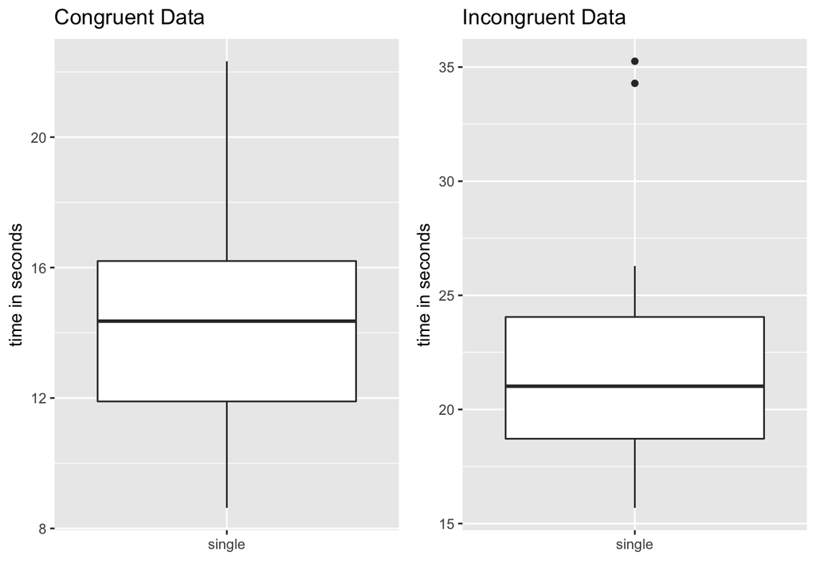

From the Boxplot, it’s clear the congruent group used less time than the incongruent group. We also found that there are two outliers in the incongruent data.

Histogram is another useful plot help us to visualize the distribution of a data. Let’s draw a histogram:

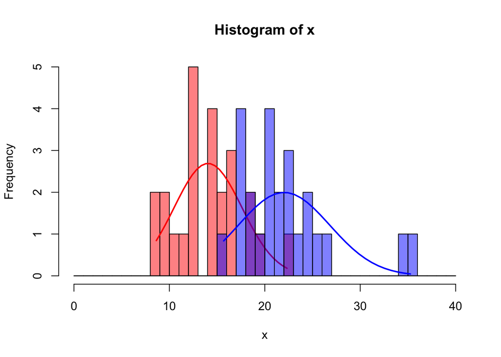

From following histogram plot, we see that the Congruent group used less time than the Incongruent group. The distribution of the Congruent data is normal, while the Incongruent data is right skewed because of the outliers (we will still consider them for our analysis unless the results for t-tests show P-value very close to 0.05, in which case we will have to double check for arriving at a final conclusion)

# Question 5

#### Now, perform the statistical test and report your results. What is your confidence level and your critical statistic value? Do you reject the null hypothesis or fail to reject it? Come to a conclusion in terms of the experiment task. Did the results match up with your expectations?

Using t.test function from R to get statistical information for stroop effect data:

```
##
##  Paired t-test
##
## data:  stroopdata$Congruent and stroopdata$Incongruent
## t = -8.0207, df = 23, p-value = 4.103e-08
## alternative hypothesis: true difference in means is not equal to 0
## 95 percent confidence interval:
##  -10.019028  -5.910555
## sample estimates:
## mean of the differences
##               -7.964792
```

we successfully rejected our Null hypothesis as P-value is less than 0.05 and conclude that we are 95 confident that it takes a longer time to read words under incongruent condition than under congruent condition. The result matched up with my expectation because when I did the experiment I spent significantly more time to read words under incongruent condition.

# Question 6 (Optional)

#### What do you think is responsible for the effects observed? Can you think of an alternative or similar task that would result in a similar effect?

One posible explanation can be when we see a word we can read it directly. However, when we see a color we need to first name the color then read it, which takes longer reaction time.

Some similar tasks may include: uppercase the word, randomly italicize the words, add blinking to the words etc.

# References

https://www.r-bloggers.com/

https://en.wikipedia.org/wiki/Stroop_effect

http://stackoverflow.com

https://udacity.com/